# Benthic_community_clean

Charlotte E Page

# NFI Benthic Cover data analysis and PCA

This is a script for data clean up and analysis of benthic cover data. Data collected from photoquadrats in Emily and Slaughter Bay, over two time points.

TP1: Dec (2020) TP2: April (2021)

All hard coral and algal taxa were identified to genera. Where multiple growth forms existed within each genera, data has been originally binned into these growth forms (within genera). Growth form bins for each genera will be grouped to genera for quantification of cover.

Script aims:

1. Tidy data format (long)
2. Filter coral genera into categories based on cover.
3. PCA - Generate driver variables that can be used in modelling disease occurence and disease severity.

Data download and tidy

```r
library(ggplot2)
library(tidyr)
library(dplyr)
library(ggthemes)
library(factoextra)
library(tidymodels)

# Visualising PCA analysis results

cover <- read.csv(file= "NFI_cover_data.csv", header = TRUE)

str(cover)
```

```
'data.frame':   234 obs. of  69 variables:
 $ Image_ID             : int  2032455 2032454 2032453 2032452 2032451 2032450 2032400 2032409 2032408 2032407 ...
 $ Image                : chr  "April_EB0_#1.png" "April_EB0_#2.png" "April_EB0_#3.png" "April_EB0_#4.png" ...
 $ Date                 : chr  "April" "April" "April" "April" ...
 $ Transect             : int  1 1 1 1 1 1 2 2 2 2 ...
 $ Transect_ID          : chr  "EB0" "EB0" "EB0" "EB0" ...
 $ PQ                   : int  1 2 3 4 5 6 10 1 2 3 ...
 $ Points               : int  100 100 100 100 100 100 100 100 100 100 ...
 $ Acanthastrea         : int  0 0 0 0 0 0 0 0 0 0 ...
 $ Acropora_br          : int  11 59 23 5 0 56 0 0 0 0 ...
 $ Acropora_pl          : int  0 3 77 87 0 0 0 0 0 94 ...
 $ Alveopora            : int  0 0 0 0 0 0 0 0 0 0 ...
 $ Astrea               : int  22 0 0 0 0 0 0 0 0 0 ...
 $ Cyphastrea           : int  0 0 0 0 0 0 0 0 0 0 ...
 $ Euphyllia            : int  0 0 0 0 0 0 0 0 0 0 ...
```

[output cut: 55 more lines]

### A) Tidy data format (long)

```r
# Transpose the data frame
t.cover <- cover %>% gather(Genera, Cover, Acanthastrea:Valonia)
str(t.cover)
```

```
'data.frame':   14508 obs. of  9 variables:
 $ Image_ID   : int  2032455 2032454 2032453 2032452 2032451 2032450 2032400 2032409 2032408 2032407 ...
 $ Image      : chr  "April_EB0_#1.png" "April_EB0_#2.png" "April_EB0_#3.png" "April_EB0_#4.png" ...
 $ Date       : chr  "April" "April" "April" "April" ...
 $ Transect   : int  1 1 1 1 1 1 2 2 2 2 ...
 $ Transect_ID: chr  "EB0" "EB0" "EB0" "EB0" ...
 $ PQ         : int  1 2 3 4 5 6 10 1 2 3 ...
 $ Points     : int  100 100 100 100 100 100 100 100 100 100 ...
 $ Genera     : chr  "Acanthastrea" "Acanthastrea" "Acanthastrea" "Acanthastrea" ...
 $ Cover      : int  0 0 0 0 0 0 0 0 0 0 ...
```

```r
# Generate some summary plots

# Summarise cover by Date, genera and transect
t.cover.freq <- t.cover %>% group_by(Date,Transect_ID,Genera) %>%
  summarise(freq = mean(Cover))
# Average across transects for plot
cover.sum <- t.cover.freq %>%
  group_by(Date, Genera) %>%
  summarise(mean.freq =mean(freq),
  SD_freq = sd(freq),
  SE_freq = sd(freq)/sqrt(n()))
str(cover.sum)
```

```
grouped_df [124 × 5] (S3: grouped_df/tbl_df/tbl/data.frame)
 $ Date     : chr [1:124] "April" "April" "April" "April" ...
 $ Genera   : chr [1:124] "Acanthastrea" "Acropora_br" "Acropora_pl" "Alveopora" ...
 $ mean.freq: num [1:124] 0.875 4.4765 8.377 0.0644 0.05 ...
 $ SD_freq  : num [1:124] 2.03 7.731 11.151 0.133 0.124 ...
 $ SE_freq  : num [1:124] 0.586 2.2318 3.2192 0.0384 0.0359 ...
 - attr(*, "groups")= tibble [2 × 2] (S3: tbl_df/tbl/data.frame)
  ..$ Date : chr [1:2] "April" "Dec"
  ..$ .rows: list<int> [1:2]
  .. ..$ : int [1:62] 1 2 3 4 5 6 7 8 9 10 ...
  .. ..$ : int [1:62] 63 64 65 66 67 68 69 70 71 72 ...
  .. ..@ ptype: int(0)
  ..- attr(*, ".drop")= logi TRUE
```

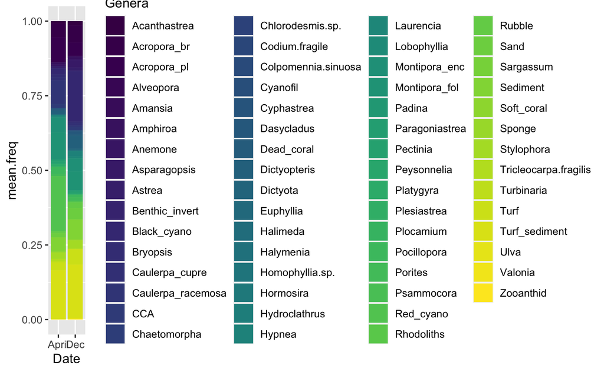

```r
ggplot(cover.sum, aes(x = Date, y = mean.freq, fill = Genera)) +
      geom_bar(position="fill", stat="identity") + scale_fill_viridis_d()
```

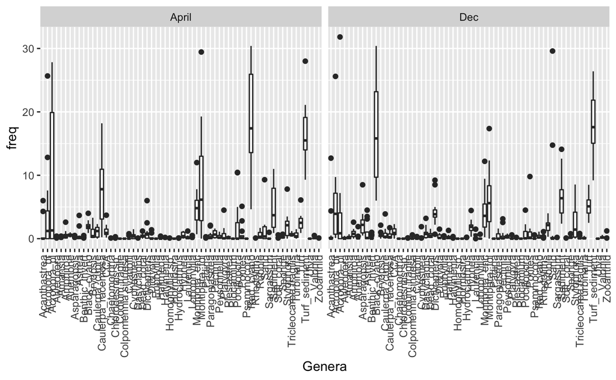

```r
ggplot(t.cover.freq, aes(x = Genera, y = freq)) +
      geom_boxplot() +
      facet_wrap(~Date) +
theme(axis.text.x = element_text(angle = 90, vjust = 0.5, hjust=1))
```

Organise cover ID into categories

```r
# Nested if else to create a new variable where genera are sorted into benthic category type.

# First list the values in the Genera column

# levels(t.cover.freq$Genera)

benthic.cats <- t.cover.freq %>%
  mutate(Category =
      ifelse(Genera %in% c("Acanthastrea", "Acropora_br", "Acropora_pl", "Alveopora","Astrea","Euphyllia", "Montipora_enc","Montipora_fol","Paragoniastrea","Pectinia","Platygyra", "Plesiastrea","Pocillopora","Porites","Psammocora","Stylophora","Cyphastrea","Homophyllia.sp.","Lobophyllia","Turbinaria"),
             "Hard_coral",
      ifelse(Genera %in% c("Amansia","Amphiroa","Asparagopsis","Bryopsis","Caulerpa_cupre","Caulerpa_racemosa", "Chaetomorpha","Chlorodesmis.sp.","Codium.fragile","Colpomennia.sinuosa","Dasycladus","Dictyopteris","Dictyota","Halimeda","Halymenia","Homophyllia.sp", "Hormosira","Hydroclathrus","Hypnea","Laurencia","Padina","Peysonnelia","Plocamium","Sargassum","Ulva","Valonia","Tricleocarpa.fragilis"),
             "Macroalgae",
      ifelse(Genera %in% c("Soft_coral","Anemone"),
             "Soft_coral",
      ifelse(Genera %in% c("Sponge","Zooanthid","Benthic_invert"),
             "Other_benthic_invert",
      ifelse(Genera %in% c("Black_cyano","Cyanofil","Red_cyano","Turf","Turf_sediment"),
               "Turf_mixed",
      ifelse(Genera %in% c("Sediment","Sand","Rubble","Dead_coral"),
             "Other_substrate",
      ifelse(Genera %in% c("CCA","Rhodoliths"),
             "Coralline_algae", "NA"
             ))))))))

# Search for any NAs

filter(benthic.cats, Category == "NA")
```

| Date | Transect_ID | Genera | freq | Category |
| --- | --- | --- | --- | --- |

```r
# 0 rows!
```

```r
relevel(benthic.cats$Date,"April")
```

[output not shown]

### B) Filter coral genera into categories based on cover.

Find coral genera of interest (taxa < 10 % relative cover)

Acropora, Montipora, other branching (p.dam, stylo), other hermatypic coral are the dominant reef building taxa.

Recategorise cover into these categories:

```r
# Nested if else to create a new variable where genera are sorted into benthic category type.

benthic.cats.other <- t.cover.freq %>%
  mutate(Category =
      ifelse(Genera %in% c("Acanthastrea", "Alveopora","Astrea","Euphyllia","Paragoniastrea","Pectinia","Platygyra", "Plesiastrea","Porites","Psammocora","Cyphastrea","Homophyllia.sp.","Lobophyllia","Turbinaria"),
             "Hard_coral",
      ifelse(Genera %in% c("Acropora_br","Acropora_pl"),
             "Acropora",
      ifelse(Genera %in% c("Pocillopora","Stylophora"),
             "Other_branching",
      ifelse(Genera %in% c("Montipora_enc","Montipora_fol"),
             "Montipora",
      ifelse(Genera %in% c("Amansia","Amphiroa","Asparagopsis","Bryopsis","Caulerpa_cupre","Caulerpa_racemosa", "Chaetomorpha","Chlorodesmis.sp.","Codium.fragile","Colpomennia.sinuosa","Dasycladus","Dictyopteris","Dictyota","Halymenia","Homophyllia.sp", "Hormosira","Hydroclathrus","Hypnea","Laurencia","Padina","Peysonnelia","Plocamium","Sargassum","Ulva","Valonia"),
             "Macroalgae",
      ifelse(Genera %in% c("Soft_coral","Anemone"),
             "Soft_coral",
      ifelse(Genera %in% c("Sponge","Zooanthid","Benthic_invert"),
             "Other_benthic_invert",
      ifelse(Genera %in% c("Black_cyano"),
             "Lyngbya",
      ifelse(Genera %in% c("Turf"),
             "Turf",
      ifelse(Genera %in% c("Turf_sediment"),
             "Turf_sediment_matrix",
      ifelse(Genera %in% c("Cyanofil","Red_cyano"),
             "Cyano_matrix",
      ifelse(Genera %in% c("Sediment"),
             "Sediment",
      ifelse(Genera %in% c("Sand","Rubble","Dead_coral"),
             "Other_substrate",
      ifelse(Genera %in% c("CCA","Rhodoliths","Halimeda","Tricleocarpa.fragilis"),
             "Other_calcifier","NA"
             )))))))))))))))

View(benthic.cats.other)

str(benthic.cats.other)
```

```
grouped_df [1,488 × 5] (S3: grouped_df/tbl_df/tbl/data.frame)
 $ Date       : chr [1:1488] "April" "April" "April" "April" ...
 $ Transect_ID: chr [1:1488] "EB0" "EB0" "EB0" "EB0" ...
 $ Genera     : chr [1:1488] "Acanthastrea" "Acropora_br" "Acropora_pl" "Alveopora" ...
 $ freq       : num [1:1488] 0 25.7 27.8 0 0 ...
 $ Category   : chr [1:1488] "Hard_coral" "Acropora" "Acropora" "Hard_coral" ...
 - attr(*, "groups")= tibble [24 × 3] (S3: tbl_df/tbl/data.frame)
  ..$ Date       : chr [1:24] "April" "April" "April" "April" ...
  ..$ Transect_ID: chr [1:24] "EB0" "EB11" "EB2" "EB5" ...
  ..$ .rows      : list<int> [1:24]
  .. ..$ : int [1:62] 1 2 3 4 5 6 7 8 9 10 ...
  .. ..$ : int [1:62] 63 64 65 66 67 68 69 70 71 72 ...
  .. ..$ : int [1:62] 125 126 127 128 129 130 131 132 133 134 ...
  .. ..$ : int [1:62] 187 188 189 190 191 192 193 194 195 196 ...
  .. ..$ : int [1:62] 249 250 251 252 253 254 255 256 257 258 ...
  .. ..$ : int [1:62] 311 312 313 314 315 316 317 318 319 320 ...
  .. ..$ : int [1:62] 373 374 375 376 377 378 379 380 381 382 ...
  .. ..$ : int [1:62] 435 436 437 438 439 440 441 442 443 444 ...
  .. ..$ : int [1:62] 497 498 499 500 501 502 503 504 505 506 ...
  .. ..$ : int [1:62] 559 560 561 562 563 564 565 566 567 568 ...
  .. ..$ : int [1:62] 621 622 623 624 625 626 627 628 629 630 ...
  .. ..$ : int [1:62] 683 684 685 686 687 688 689 690 691 692 ...
  .. ..$ : int [1:62] 745 746 747 748 749 750 751 752 753 754 ...
  .. ..$ : int [1:62] 807 808 809 810 811 812 813 814 815 816 ...
  .. ..$ : int [1:62] 869 870 871 872 873 874 875 876 877 878 ...
  .. ..$ : int [1:62] 931 932 933 934 935 936 937 938 939 940 ...
  .. ..$ : int [1:62] 993 994 995 996 997 998 999 1000 1001 1002 ...
  .. ..$ : int [1:62] 1055 1056 1057 1058 1059 1060 1061 1062 1063 1064 ...
  .. ..$ : int [1:62] 1117 1118 1119 1120 1121 1122 1123 1124 1125 1126 ...
  .. ..$ : int [1:62] 1179 1180 1181 1182 1183 1184 1185 1186 1187 1188 ...
  .. ..$ : int [1:62] 1241 1242 1243 1244 1245 1246 1247 1248 1249 1250 ...
  .. ..$ : int [1:62] 1303 1304 1305 1306 1307 1308 1309 1310 1311 1312 ...
  .. ..$ : int [1:62] 1365 1366 1367 1368 1369 1370 1371 1372 1373 1374 ...
  .. ..$ : int [1:62] 1427 1428 1429 1430 1431 1432 1433 1434 1435 1436 ...
  .. ..@ ptype: int(0)
  ..- attr(*, ".drop")= logi TRUE
```

```r
benthic.cats.other$Category <- as.factor(benthic.cats.other$Category)


# Relevel Date so that December comes first
benthic.cats.other$Date <- factor(benthic.cats.other$Date, levels = c("Dec", "April"))
```

```r
# Look at the levels
levels(benthic.cats$Category)
```

```r
head(benthic.cats)
```

| Date | Transect_ID | Genera | freq | Category |
| --- | --- | --- | --- | --- |
| April | EB0 | Acanthastrea | 0.0000000 | Hard_coral |
| April | EB0 | Acropora_br | 25.6666667 | Hard_coral |
| April | EB0 | Acropora_pl | 27.8333333 | Hard_coral |
| April | EB0 | Alveopora | 0.0000000 | Hard_coral |
| April | EB0 | Amansia | 0.0000000 | Macroalgae |
| April | EB0 | Amphiroa | 0.8333333 | Macroalgae |

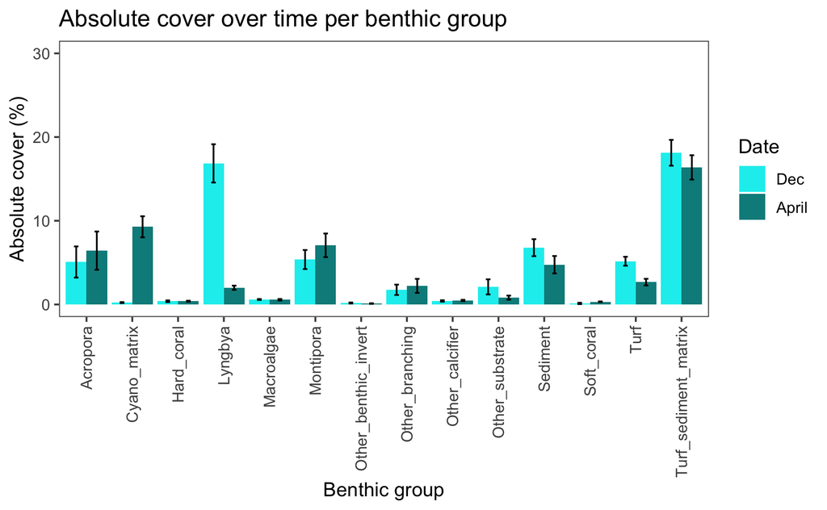

```r
# Filter out Hard_coral
hard_coral <- benthic.cats %>% filter(Category == "Hard_coral")

# Summarise data frame (per coral taxa, per time point)
benthic.cov.sum <- benthic.cats.other %>% group_by(Date,Category,Transect_ID) %>%
  summarise(rel_mean = mean(freq, na.rm = TRUE))
            #,
            #SD_freq = sd(freq),
            #SE_freq = sd(freq/sqrt(n())))

benthic.cov.sum1 <- benthic.cov.sum %>% group_by(Date,Category) %>%
  summarise(rel_sum = mean(rel_mean, na.rm = TRUE),
            SD_freq = sd(rel_mean),
            SE_freq = sd(rel_mean/sqrt(n())))
# plot relative coral cover of genera over time
colours <- c("cyan2", "darkcyan")

plot <- ggplot(benthic.cov.sum1, aes(Category, rel_sum, fill = Date)) +
 geom_col(position = "dodge",stat = "identity") +
 geom_errorbar(aes(ymin = rel_sum - SE_freq, ymax = rel_sum + SE_freq),
               width=0.2, position = position_dodge(.9), color = "black") +
  scale_y_continuous(limits = c(0,30)) +
  #geom_label(stat = 'summary', fun.y=mean, aes(label = round(..y.., 1)), nudge_x =0.5 , hjust = 3) +
  xlab ("Benthic group") +
  ylab ("Absolute cover (%)") +
  ggtitle("Absolute cover over time per benthic group") +
 theme_few() +
  scale_fill_manual(values = colours)
a <- plot + theme(axis.text.x = element_text(angle = 90, vjust = 0.5, hjust=1)) #+ #geom_hline(yintercept=10, linetype="dashed", color = "red")

a
```

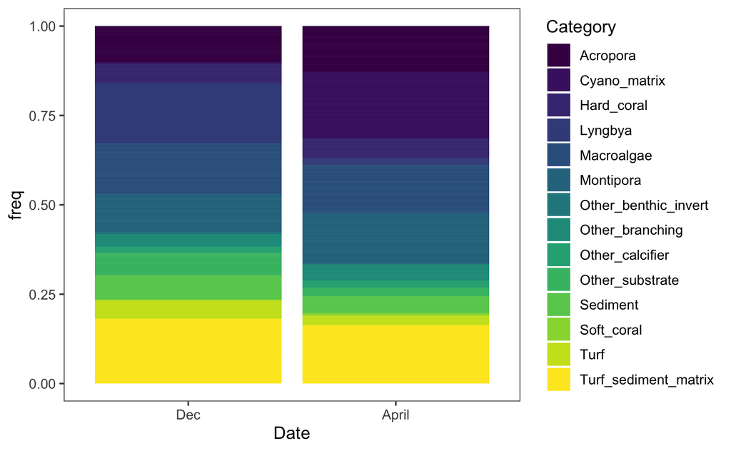

```r
ggplot(benthic.cats.other, aes(x = Date, y = freq, fill = Category)) +
      geom_bar(position="fill", stat="identity") +
      scale_fill_viridis_d() + theme_few()
```

### C) PCA - Generate driver variables that can be used in modelling disease occurence and disease severity.

Data cleaning steps

Make each group its own variable using pivot wider.

```r
str(benthic.cov.sum)
```

```
grouped_df [336 × 4] (S3: grouped_df/tbl_df/tbl/data.frame)
 $ Date       : Factor w/ 2 levels "Dec","April": 1 1 1 1 1 1 1 1 1 1 ...
 $ Category   : Factor w/ 14 levels "Acropora","Cyano_matrix",..: 1 1 1 1 1 1 1 1 1 1 ...
 $ Transect_ID: chr [1:336] "EB0" "EB11" "EB2" "EB5" ...
 $ rel_mean   : num [1:336] 16.4 0.7 0.05 1.9 1.75 ...
 - attr(*, "groups")= tibble [28 × 3] (S3: tbl_df/tbl/data.frame)
  ..$ Date    : Factor w/ 2 levels "Dec","April": 1 1 1 1 1 1 1 1 1 1 ...
  ..$ Category: Factor w/ 14 levels "Acropora","Cyano_matrix",..: 1 2 3 4 5 6 7 8 9 10 ...
  ..$ .rows   : list<int> [1:28]
  .. ..$ : int [1:12] 1 2 3 4 5 6 7 8 9 10 ...
  .. ..$ : int [1:12] 13 14 15 16 17 18 19 20 21 22 ...
  .. ..$ : int [1:12] 25 26 27 28 29 30 31 32 33 34 ...
  .. ..$ : int [1:12] 37 38 39 40 41 42 43 44 45 46 ...
  .. ..$ : int [1:12] 49 50 51 52 53 54 55 56 57 58 ...
  .. ..$ : int [1:12] 61 62 63 64 65 66 67 68 69 70 ...
  .. ..$ : int [1:12] 73 74 75 76 77 78 79 80 81 82 ...
  .. ..$ : int [1:12] 85 86 87 88 89 90 91 92 93 94 ...
  .. ..$ : int [1:12] 97 98 99 100 101 102 103 104 105 106 ...
  .. ..$ : int [1:12] 109 110 111 112 113 114 115 116 117 118 ...
  .. ..$ : int [1:12] 121 122 123 124 125 126 127 128 129 130 ...
  .. ..$ : int [1:12] 133 134 135 136 137 138 139 140 141 142 ...
  .. ..$ : int [1:12] 145 146 147 148 149 150 151 152 153 154 ...
  .. ..$ : int [1:12] 157 158 159 160 161 162 163 164 165 166 ...
  .. ..$ : int [1:12] 169 170 171 172 173 174 175 176 177 178 ...
  .. ..$ : int [1:12] 181 182 183 184 185 186 187 188 189 190 ...
  .. ..$ : int [1:12] 193 194 195 196 197 198 199 200 201 202 ...
  .. ..$ : int [1:12] 205 206 207 208 209 210 211 212 213 214 ...
  .. ..$ : int [1:12] 217 218 219 220 221 222 223 224 225 226 ...
  .. ..$ : int [1:12] 229 230 231 232 233 234 235 236 237 238 ...
  .. ..$ : int [1:12] 241 242 243 244 245 246 247 248 249 250 ...
  .. ..$ : int [1:12] 253 254 255 256 257 258 259 260 261 262 ...
  .. ..$ : int [1:12] 265 266 267 268 269 270 271 272 273 274 ...
  .. ..$ : int [1:12] 277 278 279 280 281 282 283 284 285 286 ...
  .. ..$ : int [1:12] 289 290 291 292 293 294 295 296 297 298 ...
  .. ..$ : int [1:12] 301 302 303 304 305 306 307 308 309 310 ...
  .. ..$ : int [1:12] 313 314 315 316 317 318 319 320 321 322 ...
  .. ..$ : int [1:12] 325 326 327 328 329 330 331 332 333 334 ...
  .. ..@ ptype: int(0)
  ..- attr(*, ".drop")= logi TRUE
```

```r
# Transpose data-set
# Rows for each category, for 24 transects.

# Use pivot wider to

wide.benthic.cats <- benthic.cov.sum %>% pivot_wider(names_from = Category, values_from = rel_mean)
str(wide.benthic.cats)
```

```
grouped_df [24 × 16] (S3: grouped_df/tbl_df/tbl/data.frame)
 $ Date                : Factor w/ 2 levels "Dec","April": 1 1 1 1 1 1 1 1 1 1 ...
 $ Transect_ID         : chr [1:24] "EB0" "EB11" "EB2" "EB5" ...
 $ Acropora            : num [1:24] 16.4 0.7 0.05 1.9 1.75 ...
 $ Cyano_matrix        : num [1:24] 0.05 0.5 0.05 0.15 0.05 ...
 $ Hard_coral          : num [1:24] 0.236 0.157 1.25 0.343 0.15 ...
 $ Lyngbya             : num [1:24] 9.8 26.8 25.4 12.8 16.9 ...
 $ Macroalgae          : num [1:24] 0.758 0.613 0.354 0.958 0.517 ...
 $ Montipora           : num [1:24] 3.65 3.3 10.35 1.4 3.1 ...
 $ Other_benthic_invert: num [1:24] 0.3667 0.1 0.0333 0.1 0.2 ...
 $ Other_branching     : num [1:24] 0 2.85 0.25 0 0.15 ...
 $ Other_calcifier     : num [1:24] 0.3 0.975 0.275 0.8 0.15 ...
 $ Other_substrate     : num [1:24] 0.133 0.8 1.233 0.433 10.6 ...
 $ Sediment            : num [1:24] 4.1 7.8 7.7 14.1 6.8 ...
 $ Soft_coral          : num [1:24] 0 0 0 0.05 1 ...
 $ Turf                : num [1:24] 8.5 2.5 5.4 7.1 4.2 ...
 $ Turf_sediment_matrix: num [1:24] 13.2 24.7 9.2 26.4 12.5 ...
 - attr(*, "groups")= tibble [2 × 2] (S3: tbl_df/tbl/data.frame)
  ..$ Date : Factor w/ 2 levels "Dec","April": 1 2
  ..$ .rows: list<int> [1:2]
  .. ..$ : int [1:12] 1 2 3 4 5 6 7 8 9 10 ...
  .. ..$ : int [1:12] 13 14 15 16 17 18 19 20 21 22 ...
  .. ..@ ptype: int(0)
  ..- attr(*, ".drop")= logi TRUE
```

```r
# Add total hard coral onto this and write a csv file.
head(hc_trana)
```

[output not shown]

Look for correlations between variables

Correlation matrix

```r
str(wide.benthic.cats)
```

```
grouped_df [24 × 16] (S3: grouped_df/tbl_df/tbl/data.frame)
 $ Date                : Factor w/ 2 levels "Dec","April": 1 1 1 1 1 1 1 1 1 1 ...
 $ Transect_ID         : chr [1:24] "EB0" "EB11" "EB2" "EB5" ...
 $ Acropora            : num [1:24] 16.4 0.7 0.05 1.9 1.75 ...
 $ Cyano_matrix        : num [1:24] 0.05 0.5 0.05 0.15 0.05 ...
 $ Hard_coral          : num [1:24] 0.236 0.157 1.25 0.343 0.15 ...
 $ Lyngbya             : num [1:24] 9.8 26.8 25.4 12.8 16.9 ...
 $ Macroalgae          : num [1:24] 0.758 0.613 0.354 0.958 0.517 ...
 $ Montipora           : num [1:24] 3.65 3.3 10.35 1.4 3.1 ...
 $ Other_benthic_invert: num [1:24] 0.3667 0.1 0.0333 0.1 0.2 ...
 $ Other_branching     : num [1:24] 0 2.85 0.25 0 0.15 ...
 $ Other_calcifier     : num [1:24] 0.3 0.975 0.275 0.8 0.15 ...
 $ Other_substrate     : num [1:24] 0.133 0.8 1.233 0.433 10.6 ...
 $ Sediment            : num [1:24] 4.1 7.8 7.7 14.1 6.8 ...
 $ Soft_coral          : num [1:24] 0 0 0 0.05 1 ...
 $ Turf                : num [1:24] 8.5 2.5 5.4 7.1 4.2 ...
 $ Turf_sediment_matrix: num [1:24] 13.2 24.7 9.2 26.4 12.5 ...
 - attr(*, "groups")= tibble [2 × 2] (S3: tbl_df/tbl/data.frame)
  ..$ Date : Factor w/ 2 levels "Dec","April": 1 2
  ..$ .rows: list<int> [1:2]
  .. ..$ : int [1:12] 1 2 3 4 5 6 7 8 9 10 ...
  .. ..$ : int [1:12] 13 14 15 16 17 18 19 20 21 22 ...
  .. ..@ ptype: int(0)
  ..- attr(*, ".drop")= logi TRUE
```

```r
res <- cor(wide.benthic.cats[,c(3:16)])
round(res, 2)
```

```
                     Acropora Cyano_matrix Hard_coral Lyngbya Macroalgae Montipora
Acropora                 1.00        -0.03      -0.16   -0.17      -0.31     -0.42
Cyano_matrix            -0.03         1.00      -0.07   -0.67      -0.02      0.21
Hard_coral              -0.16        -0.07       1.00    0.03      -0.16      0.18
Lyngbya                 -0.17        -0.67       0.03    1.00      -0.03     -0.20
Macroalgae              -0.31        -0.02      -0.16   -0.03       1.00     -0.38
Montipora               -0.42         0.21       0.18   -0.20      -0.38      1.00
Other_benthic_invert     0.01        -0.26      -0.13    0.18       0.34     -0.40
Other_branching         -0.05        -0.21       0.10   -0.20      -0.22      0.34
Other_calcifier         -0.18         0.18      -0.39    0.02       0.41     -0.15
Other_substrate         -0.23        -0.28      -0.09    0.17      -0.01     -0.17
Sediment                -0.54        -0.24       0.08    0.27       0.30     -0.11
Soft_coral              -0.10         0.25      -0.05   -0.41      -0.08      0.05
Turf                     0.17        -0.49      -0.12    0.48       0.10     -0.22
Turf_sediment_matrix    -0.44        -0.19      -0.22    0.05       0.39     -0.18
                     Other_benthic_invert Other_branching Other_calcifier Other_substrate Sediment
Acropora                             0.01           -0.05           -0.18           -0.23    -0.54
Cyano_matrix                        -0.26           -0.21            0.18           -0.28    -0.24
Hard_coral                          -0.13            0.10           -0.39           -0.09     0.08
Lyngbya                              0.18           -0.20            0.02            0.17     0.27
Macroalgae                           0.34           -0.22            0.41           -0.01     0.30
Montipora                           -0.40            0.34           -0.15           -0.17    -0.11
Other_benthic_invert                 1.00           -0.01           -0.15            0.16     0.18
Other_branching                     -0.01            1.00           -0.05           -0.23    -0.38
Other_calcifier                     -0.15           -0.05            1.00           -0.30     0.03
Other_substrate                      0.16           -0.23           -0.30            1.00     0.36
Sediment                             0.18           -0.38            0.03            0.36     1.00
Soft_coral                          -0.08            0.06           -0.24            0.60    -0.09
Turf                                 0.08           -0.23            0.13           -0.07     0.11
Turf_sediment_matrix                 0.14            0.25            0.36           -0.04     0.42
                     Soft_coral  Turf Turf_sediment_matrix
Acropora                  -0.10  0.17                -0.44
Cyano_matrix               0.25 -0.49                -0.19
Hard_coral                -0.05 -0.12                -0.22
Lyngbya                   -0.41  0.48                 0.05
Macroalgae                -0.08  0.10                 0.39
Montipora                  0.05 -0.22                -0.18
Other_benthic_invert      -0.08  0.08                 0.14
Other_branching            0.06 -0.23                 0.25
Other_calcifier           -0.24  0.13                 0.36
Other_substrate            0.60 -0.07                -0.04
Sediment                  -0.09  0.11                 0.42
Soft_coral                 1.00 -0.50                -0.12
Turf                      -0.50  1.00                -0.08
Turf_sediment_matrix      -0.12 -0.08                 1.00
```